# R Notebook

Load Library

### Read Data

```r
oldw <- getOption("warn")
options(warn = -1)

dt <- read_excel("../Data/groundwater.xlsx")
glimpse(dt)
```

```
## Observations: 64,628
## Variables: 32
## $ Season               <chr> "Spring ", "Spring ", "Spring ", "Spring ...
## $ Year                 <dbl> 2011, 2011, 2011, 2011, 2011, 2011, 2011,...
## $ Measurement Type     <chr> "Depth", "Depth", "Depth", "Depth", "Dept...
## $ Time Period          <chr> "1 yr", "1 yr", "1 yr", "1 yr", "1 yr", "...
## $ Site_Code            <chr> "332367N1167165W001", "332486N1166558W001...
## $ Local_Well           <chr> "90", "82", "82", "43", "29", "MCAS-3/MP2...
## $ State_Well           <chr> "11S03E06D001S", "11S03E03G001S", "11S03E...
## $ WCR_Number           <chr> NA, "09617", "09617", NA, NA, "255941", "...
## $ Well_Use             <dbl> 1, 1, 1, 1, 1, 1, 1, 1, 1, 1, 1, 1, 1, 1,...
## $ Msmt_Date            <dttm> 2011-03-15, 2011-03-15, 2011-03-15, 2011...
## $ Msmt_Agenc           <dbl> 5062, 5062, 5062, 5062, 5062, 5045, 5045,...
## $ WSEL                 <dbl> 2704.900, 2986.350, 2986.350, 2799.420, 2...
## $ DGBS                 <dbl> 31.10, 0.65, 0.65, 22.58, 110.91, 80.39, ...
```

[output cut: 19 more lines]

```r
options(warn = oldw)
```

### Data Checking and Cleaning

```r
dt <- dt %>% filter(`Measurement Type`=='Depth') %>% select(Season, Year, Msmt_Date, Latitude, Longitude, WSEL, Basin_ID, Basin_Name)
dim(dt)
```

```
## [1] 36644     8
```

```r
dt <- dt %>% mutate(Latitude = round(Latitude, 6), Longitude = round(Longitude,6))
ndt <- dt %>% distinct(Season, Year, Latitude, Longitude, .keep_all = TRUE) %>%
        mutate(Month = month(Msmt_Date)) %>%
        dplyr::select(Year, Season, Month, Latitude,Longitude, Basin_Name,WSEL)
ndt$place = paste(ndt$Longitude,ndt$Latitude,sep="_")
dim(ndt)
```

```
## [1] 33307     8
```

```r
n_distinct(ndt$place) #13820 locations
```

```
## [1] 13820
```

```r
sum(is.na(dt$Latitude)) #no missing values
```

```
## [1] 0
```

```r
sum(is.na(dt$Longitude))#no missing values
```

```
## [1] 0
```

```r
sum(is.na(dt$Basin_Name))
```

```
## [1] 713
```

```r
sum(is.na(dt$Msmt_Date))#no missing values
```

```
## [1] 0
```

### How often are the basin areas measured by sensors yearly?

```r
sites_df <- ndt %>% group_by(Basin_Name, Year) %>%
     summarise(num_of_measures = n(), num_of_locs = n_distinct(place))
write.csv(sites_df,file = "../Data/basin_measurements.csv",na = "unknown",row.names = FALSE)
sites_df
```

```
## Source: local data frame [678 x 4]
## Groups: Basin_Name [?]
##
##           Basin_Name  Year num_of_measures num_of_locs
##                <chr> <dbl>           <int>       <int>
## 1  ADOBE LAKE VALLEY  2013               3           2
## 2  ADOBE LAKE VALLEY  2014               5           4
## 3  ADOBE LAKE VALLEY  2015               2           1
## 4   ALEXANDER VALLEY  2012               8           8
## 5   ALEXANDER VALLEY  2013               9           8
## 6   ALEXANDER VALLEY  2014              22          21
## 7   ALEXANDER VALLEY  2015              10           7
## 8   ALEXANDER VALLEY  2016               6           6
## 9       ALTURAS AREA  2011               4           4
## 10      ALTURAS AREA  2012               4           4
## # ... with 668 more rows
```

Clean the data by year and Season to get the average WSEL since there are possibly several measurements on a specific location at a certain time point.

```r
dt_season <- ndt %>% group_by(place, Year, Season) %>% summarise(avg_WSEL = mean(WSEL))

dt_target <- dt_season %>% left_join(ndt)
```

## Apply Bayesian Spatio-Temporal Model

The goal is to interpolate and forcast the WSEL values accounting for the spatial and temporal random effect in the model. The advantage of this model lies in the flexibility to apply bayesian method to fit the missing values and take both the spatial and temporal random effect into accounts to get robust estimates.

### Prepare Monthly Sample Data for Sacromento Valley

```r
test = ndt %>% filter(Basin_Name=='SACRAMENTO VALLEY')
test
```

```
## # A tibble: 7,112 × 8
##     Year  Season Month Latitude Longitude        Basin_Name   WSEL
##    <dbl>   <chr> <dbl>    <dbl>     <dbl>             <chr>  <dbl>
## 1   2011 Spring      4  38.1724 -121.7450 SACRAMENTO VALLEY  24.47
## 2   2011 Spring      4  38.2209 -121.8365 SACRAMENTO VALLEY  52.92
## 3   2011 Spring      4  38.2302 -121.7126 SACRAMENTO VALLEY  -0.85
## 4   2011 Spring      4  38.2454 -121.7027 SACRAMENTO VALLEY  -0.35
## 5   2011 Spring      3  38.2606 -121.8046 SACRAMENTO VALLEY  11.40
## 6   2011 Spring      3  38.2864 -121.7883 SACRAMENTO VALLEY  10.60
## 7   2011 Spring      4  38.2939 -121.3904 SACRAMENTO VALLEY   3.36
## 8   2011 Spring      4  38.3009 -121.4224 SACRAMENTO VALLEY -15.01
## 9   2011 Spring      3  38.3223 -121.8701 SACRAMENTO VALLEY  41.64
## 10  2011 Spring      4  38.3270 -121.4736 SACRAMENTO VALLEY -10.08
## # ... with 7,102 more rows, and 1 more variables: place <chr>
```

To apply the B.S.T Model in SpTimer package, we need to carefully remove the locations too close with each others, which is probably due to some computation issues.

```r
cat("number of wells in Sacromento Valley:", n_distinct(test$place), '\n')
```

```
## number of wells in Sacromento Valley: 2331
```

```r
loc_df <- as.matrix(unique(test[,c("Longitude","Latitude")]))
fdm <- spT.geodist(loc_df[,1],loc_df[,2])
diag(fdm)<-NA
fdm<-cbind(c(fdm),1:dim(fdm)[[2]],sort(rep(1:dim(fdm)[[1]],dim(fdm)[[2]])))
fdm<-fdm[!is.na(fdm[,1]),]
tol <- 0.08
fdmis<-fdm[fdm[,1] < tol,] #sites too close
site_Todelete = unique(c(fdmis[,2],fdmis[,3]))
cat("number of well locations being too close with each other: ",length(site_Todelete),'\n')
```

```
## number of well locations being too close with each other:  1996
```

```r
loc_df = as.data.frame(loc_df)
loc_df$site_id = 1:dim(loc_df)[1]

nloc_df = loc_df %>% filter(!site_id %in% site_Todelete)
ntest <- left_join(nloc_df, test)
ntest %>% group_by(Year,Season) %>% summarise(cnt=n())
```

```
## Source: local data frame [9 x 3]
## Groups: Year [?]
##
##    Year  Season   cnt
##   <dbl>   <chr> <int>
## 1  2011 Spring      8
## 2  2012 Spring     18
## 3  2013    Fall    93
## 4  2013  Spring    11
## 5  2014    Fall    78
## 6  2014 Spring     37
## 7  2015    Fall   171
## 8  2015  Spring    67
## 9  2016 Spring    238
```

Prepare the expanded dataset with the missing values on the other months

```r
#N <- n_distinct(ntest$place) #335
place_ls <- unique(ntest$place)
sample_locs <- sample(place_ls,100,replace = FALSE)

N <- length(sample_locs)
Y <- n_distinct(ntest$Year)
all_data <- data.frame(matrix(NA, N*Y*2, 3))

all_data[,1] <- as.character(rep(sample_locs, each = Y*2))
all_data[,2] <- as.numeric(2011:2016, each = 2)
all_data[,3] <- as.character(c("Spring","Fall"))
colnames(all_data) <- c("place", "Year", "Season")

nall_data <- left_join(all_data, ntest)
nall_data$Latitude = sapply(nall_data[,"place"],function(x) as.numeric(strsplit(x, split='_')[[1]][1]))
nall_data$Longitude = sapply(nall_data[,"place"],function(x) as.numeric(strsplit(x, split='_')[[1]][2]))
```

```r
dim(nall_data)
```

```
## [1] 1200    9
```

```r
sum(is.na(nall_data$WSEL))/dim(nall_data)[1] #85%
```

```
## [1] 0.9233333
```

```r
head(nall_data)
```

```
##                 place Year Season Longitude  Latitude site_id Month
## 1 -121.94776_39.20427 2011 Spring  39.20427 -121.9478      NA    NA
## 2 -121.94776_39.20427 2012   Fall  39.20427 -121.9478      NA    NA
## 3 -121.94776_39.20427 2013 Spring  39.20427 -121.9478      NA    NA
## 4 -121.94776_39.20427 2014   Fall  39.20427 -121.9478      NA    NA
## 5 -121.94776_39.20427 2015 Spring  39.20427 -121.9478      NA    NA
## 6 -121.94776_39.20427 2016   Fall  39.20427 -121.9478      NA    NA
##   Basin_Name WSEL
## 1       <NA>   NA
## 2       <NA>   NA
## 3       <NA>   NA
## 4       <NA>   NA
## 5       <NA>   NA
## 6       <NA>   NA
```

The distribution of WSEL. We may consider to transform the variable to make it noraml to improve our modeling.

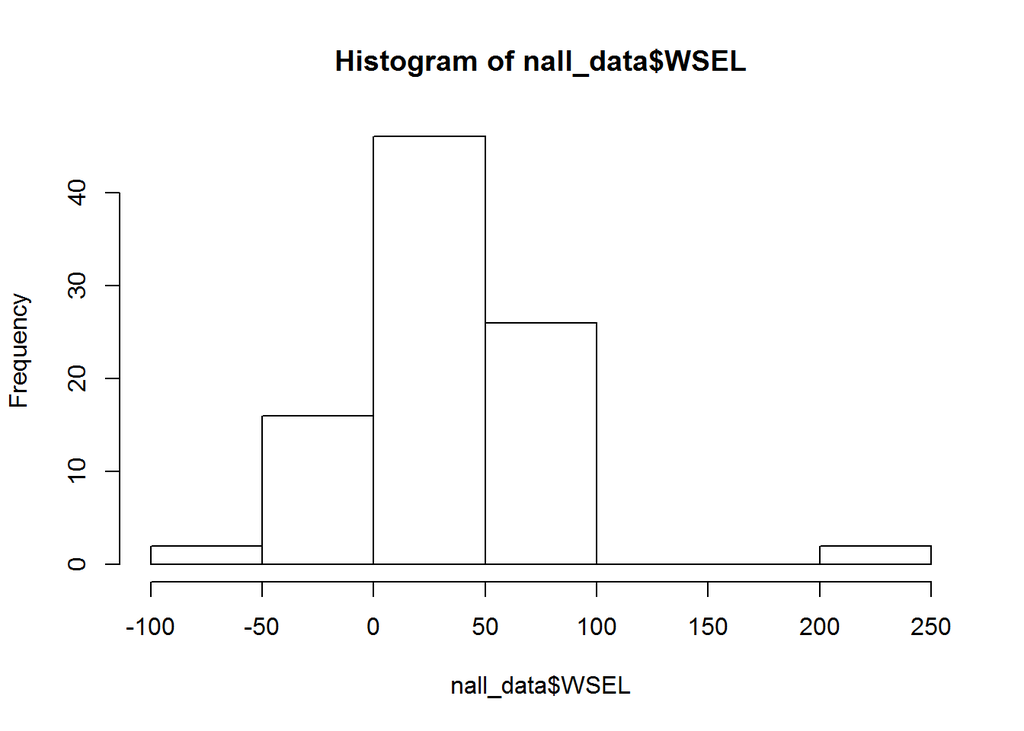

```r
hist(nall_data$WSEL)
```

### Choose the Gaussian Process method with the default prior

```r
nItr <- 1000  # number of MCMC samples for each model, used as 5000 in the paper
nBurn <- 100  # number of burn-in from the MCMC samples, used as 1000 in the paper

gdwater.gp <- spT.Gibbs(formula= WSEL~ 1, data=nall_data,
                        model="GP",
                        ts <- spT.time(t.series = 2,
                                       segments = 6),
                        coords= ~Longitude + Latitude,
                        nItr = nItr, nBurn = nBurn,
              spatial.decay=spT.decay(distribution=Gamm(2,1),tuning=0.1))
```

```
##
##  Output: GP models
## ---------------------------------------------------------------
##  Sampled: 1000 of 1000, 100.00%.
##  Batch Acceptance Rate (phi): 52.65%
##  Checking Parameters:
##    phi: 3.7292, sig2eps: 1916.5652, sig2eta: 147.5074
##    beta[1]: 34.2773
## ---------------------------------------------------------------
## ##
## # nBurn =  100 , Iterations =  1000 .
## # Overall Acceptance Rate (phi) =  52.6 %
## ##
## ##
## # Elapsed time: 15.41 Sec.
## ##
##
## # Model: GP
```

```r
print(gdwater.gp)
```

```
## -----------------------------------------------------
## Model: GP
## Call: WSEL ~ 1
## Iterations: 1000
## nBurn: 100
## Acceptance rate for phi (%): 52.6
## -----------------------------------------------------
##         Goodness.of.fit Penalty     PMCC
## values:        150456.4  197865 348321.4
## -----------------------------------------------------
## Computation time: 15.41  - Sec.
```

```r
summary(gdwater.gp)
```

```
## -----------------------------------------------------
## Model: GP
## Call: WSEL ~ 1
## Iterations: 1000
## nBurn: 100
## Acceptance rate for phi (%): 52.6
## -----------------------------------------------------
##         Goodness.of.fit Penalty     PMCC
## values:        150456.4  197865 348321.4
## -----------------------------------------------------
## Computation time: 15.41  - Sec.
## -----------------------------------------------------
## Parameters:
##                  Mean    Median       SD   Low2.5p   Up97.5p
## (Intercept)   34.4630   34.4655   0.3685   33.7277   35.1776
## sig2eps     2002.6115 1972.4169 332.4623 1432.5249 2761.2703
## sig2eta      151.0413  150.7796   7.0785  138.6227  164.9480
## phi            2.7773    2.7046   0.5265    1.8599    4.0170
## -----------------------------------------------------
```

Check the fitting performance

```r
spT.validation(nall_data$WSEL[!is.na(nall_data$WSEL)],gdwater.gp$fitted[,1][!is.na(nall_data$WSEL)])
```

```
## ##
##  Mean Squared Error (MSE)
##  Root Mean Squared Error (RMSE)
##  Mean Absolute Error (MAE)
##  Mean Absolute Percentage Error (MAPE)
##  Bias (BIAS)
##  Relative Bias (rBIAS)
##  Relative Mean Separation (rMSEP)
## ##
```

```
##       MSE      RMSE       MAE      MAPE      BIAS     rBIAS     rMSEP
## 1635.3961   40.4400   29.4727  -22.7190    4.9828    0.1693    0.8579
```

Model Diagnostics

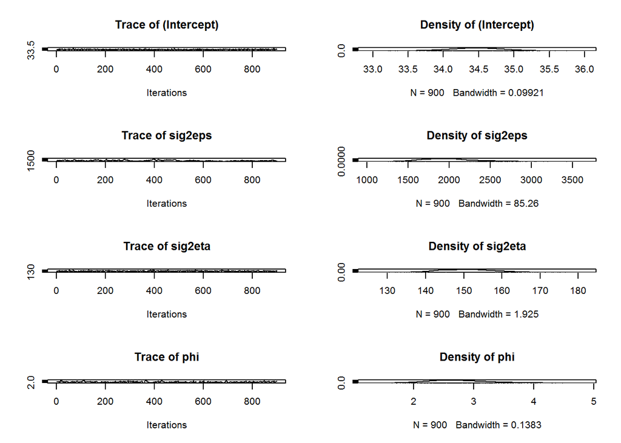

```r
plot(gdwater.gp)
```

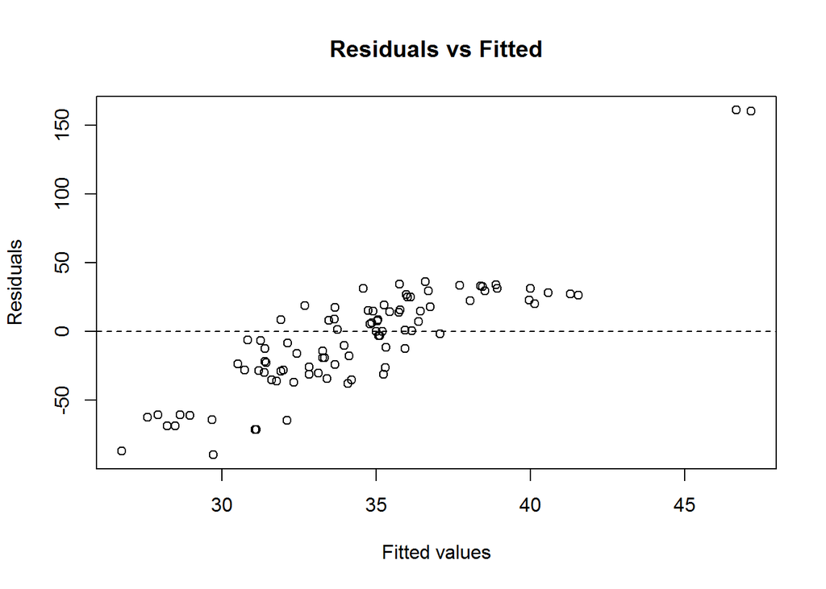

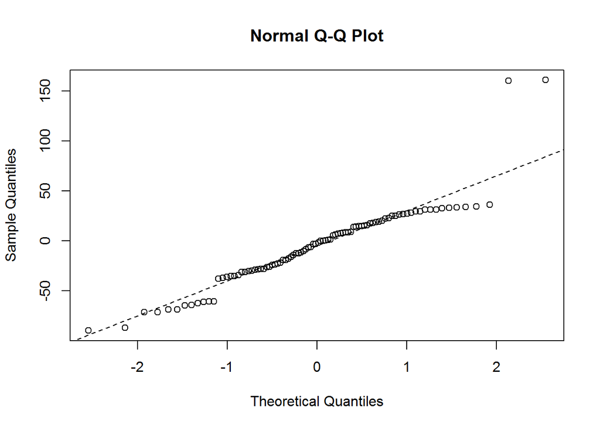

```r
plot(gdwater.gp, residuals=TRUE)
```

We want to check the predictive power. We need to create the grids of location and time in a suitable format for training.

```r
set.seed(11)

N <- n_distinct(ntest$place)
Y <- n_distinct(ntest$Year)
all_grids <- data.frame(matrix(NA, N*Y*2, 3))

all_grids[,1] <- as.character(rep(unique(ntest$place), each = Y*2))
all_grids[,2] <- as.numeric(2011:2016, each = 2)
all_grids[,3] <- as.character(c("Spring","Fall"))
colnames(all_grids) <- c("place", "Year", "Season")

all_grids <- left_join(all_grids, ntest)
all_grids$Latitude = sapply(all_grids[,"place"],function(x) as.numeric(strsplit(x, split='_')[[1]][1]))
all_grids$Longitude = sapply(all_grids[,"place"],function(x) as.numeric(strsplit(x, split='_')[[1]][2]))
```

### Generate predictions

```r
set.seed(11)
pred.gp <- predict(gdwater.gp, newdata=all_grids, newcoords=~Longitude+Latitude)
```

[output not shown]

[output cut: 549 more lines]

### Gaussian Process model2 with better prior estimate

```r
set.seed(11)
ts <- spT.time(t.series = 2, segments = 6)
nItr <- 1000  # number of MCMC samples for each model, used as 5000 in the paper
nBurn <- 100  # number of burn-in from the MCMC samples, used as 1000 in the paper

priors <- spT.priors(model = "GP", inv.var.prior = Gamm(2,1), beta.prior = Norm(72, 65)) # note that the 72 is the average WSEL from our test data

gdwater.gp2 <- spT.Gibbs(formula= WSEL~ 1, data=nall_data, model="GP", time.data = ts,
                      coords= ~Longitude + Latitude, priors = priors,
                      nItr = nItr, nBurn = nBurn,
                        spatial.decay=spT.decay(distribution=Gamm(2,1),tuning=0.1))
```

```
##
##  Output: GP models
## ---------------------------------------------------------------
##  Sampled: 1000 of 1000, 100.00%.
##  Batch Acceptance Rate (phi): 49.95%
##  Checking Parameters:
##    phi: 3.1829, sig2eps: 2006.7014, sig2eta: 149.3830
##    beta[1]: 34.3948
## ---------------------------------------------------------------
## ##
## # nBurn =  100 , Iterations =  1000 .
## # Overall Acceptance Rate (phi) =  49.9 %
## ##
## ##
## # Elapsed time: 18.47 Sec.
## ##
##
## # Model: GP
```

We can see the goodness of fit and predictive power increase comparing to last model.

```r
summary(gdwater.gp2)
```

```
## -----------------------------------------------------
## Model: GP
## Call: WSEL ~ 1
## Iterations: 1000
## nBurn: 100
## Acceptance rate for phi (%): 49.9
## -----------------------------------------------------
##         Goodness.of.fit  Penalty     PMCC
## values:        147064.3 189091.3 336155.6
## -----------------------------------------------------
## Computation time: 18.47  - Sec.
## -----------------------------------------------------
## Parameters:
##                  Mean    Median       SD   Low2.5p   Up97.5p
## (Intercept)   34.5327   34.5349   0.3755   33.7630   35.2666
## sig2eps     1928.6172 1937.0923 231.2174 1510.4246 2355.2869
## sig2eta      151.4014  150.9058   7.0634  138.7495  166.6337
## phi            2.7492    2.6880   0.4670    1.9586    3.7325
## -----------------------------------------------------
```

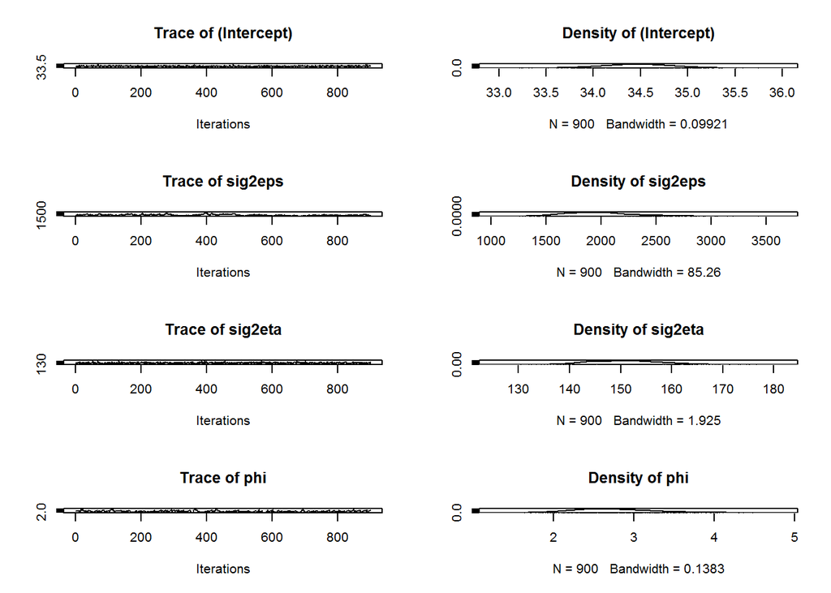

```r
plot(gdwater.gp)
```

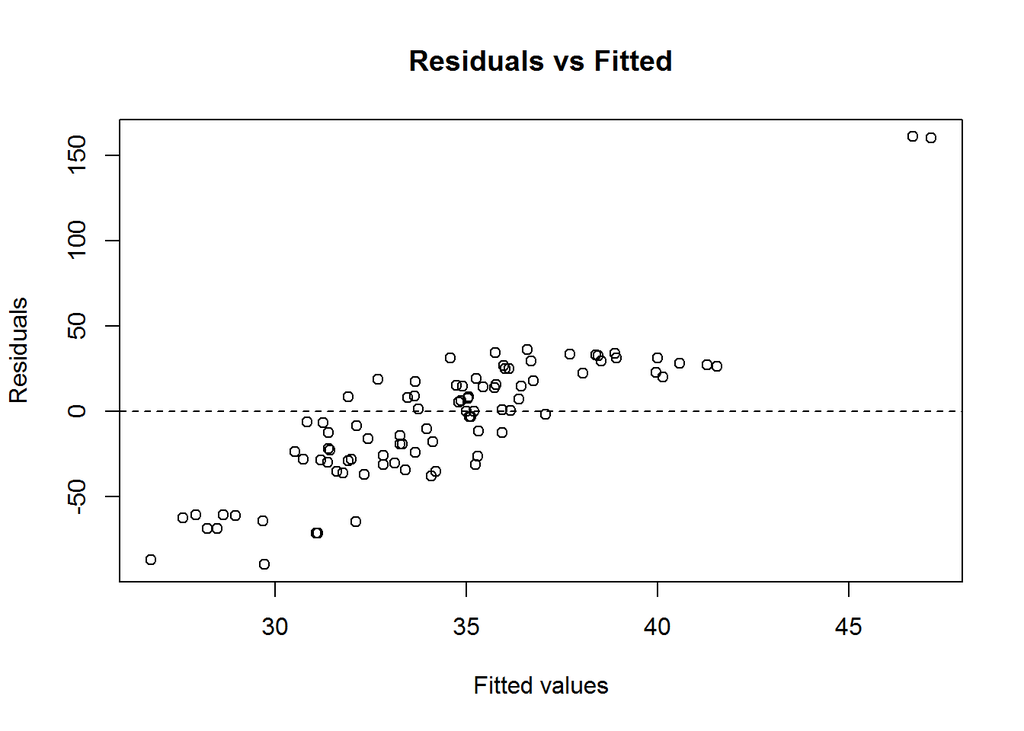

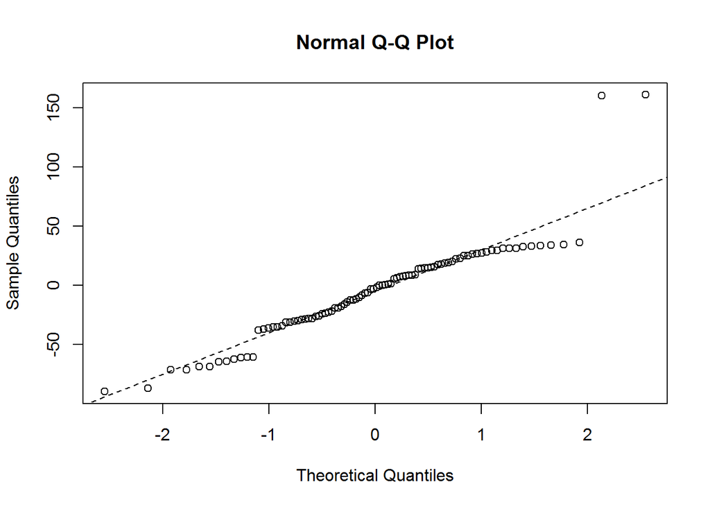

```r
plot(gdwater.gp, residuals=TRUE)
```

```r
spT.validation(nall_data$WSEL[!is.na(nall_data$WSEL)],gdwater.gp2$fitted[,1][!is.na(nall_data$WSEL)])
```

```
## ##
##  Mean Squared Error (MSE)
##  Root Mean Squared Error (RMSE)
##  Mean Absolute Error (MAE)
##  Mean Absolute Percentage Error (MAPE)
##  Bias (BIAS)
##  Relative Bias (rBIAS)
##  Relative Mean Separation (rMSEP)
## ##
```

```
##       MSE      RMSE       MAE      MAPE      BIAS     rBIAS     rMSEP
## 1598.5249   39.9816   28.9742  -23.0246    4.9549    0.1684    0.8387
```

```r
set.seed(11)
pred.gp2 <- predict(gdwater.gp2, newdata=all_grids, newcoords=~Longitude+Latitude)
```

[output not shown]

[output cut: 549 more lines]

### More work to be done

- Test and choose better priors
- Experiment with AR model
- Implement the cross-validation training process for fitting the spatio-temporal data